# DATA621_Home_Work_5

Dilip Ganesan

7/10/2018

## Home Work Assignment 5.

## 1.DATA EXPLORATION.(Exploratory Data Analysis EDA)

As first step in our EDA, let us load the train data and do a summary statistics on the loaded dataset.

```r
# Let us load the train.csv data
train = read.csv('wine-training-data.csv')
test = read.csv('wine-evaluation-data.csv')

train = within(train, rm('INDEX'))
#test = within(test, rm('INDEX'))

summary(train)
```

```
##      TARGET       FixedAcidity     VolatileAcidity     CitricAcid
##  Min.   :0.000   Min.   :-18.100   Min.   :-2.7900   Min.   :-3.2400
##  1st Qu.:2.000   1st Qu.:  5.200   1st Qu.: 0.1300   1st Qu.: 0.0300
##  Median :3.000   Median :  6.900   Median : 0.2800   Median : 0.3100
##  Mean   :3.029   Mean   :  7.076   Mean   : 0.3241   Mean   : 0.3084
##  3rd Qu.:4.000   3rd Qu.:  9.500   3rd Qu.: 0.6400   3rd Qu.: 0.5800
##  Max.   :8.000   Max.   : 34.400   Max.   : 3.6800   Max.   : 3.8600
##
##  ResidualSugar        Chlorides       FreeSulfurDioxide TotalSulfurDioxide
##  Min.   :-127.800   Min.   :-1.1710   Min.   :-555.00   Min.   :-823.0
##  1st Qu.:  -2.000   1st Qu.:-0.0310   1st Qu.:   0.00   1st Qu.:  27.0
##  Median :   3.900   Median : 0.0460   Median :  30.00   Median : 123.0
##  Mean   :   5.419   Mean   : 0.0548   Mean   :  30.85   Mean   : 120.7
##  3rd Qu.:  15.900   3rd Qu.: 0.1530   3rd Qu.:  70.00   3rd Qu.: 208.0
##  Max.   : 141.150   Max.   : 1.3510   Max.   : 623.00   Max.   :1057.0
##  NA's   :616        NA's   :638       NA's   :647       NA's   :682
##     Density             pH          Sulphates          Alcohol
##  Min.   :0.8881   Min.   :0.480   Min.   :-3.1300   Min.   :-4.70
##  1st Qu.:0.9877   1st Qu.:2.960   1st Qu.: 0.2800   1st Qu.: 9.00
##  Median :0.9945   Median :3.200   Median : 0.5000   Median :10.40
##  Mean   :0.9942   Mean   :3.208   Mean   : 0.5271   Mean   :10.49
##  3rd Qu.:1.0005   3rd Qu.:3.470   3rd Qu.: 0.8600   3rd Qu.:12.40
##  Max.   :1.0992   Max.   :6.130   Max.   : 4.2400   Max.   :26.50
##                   NA's   :395     NA's   :1210      NA's   :653
##   LabelAppeal          AcidIndex          STARS
##  Min.   :-2.000000   Min.   : 4.000   Min.   :1.000
##  1st Qu.:-1.000000   1st Qu.: 7.000   1st Qu.:1.000
##  Median : 0.000000   Median : 8.000   Median :2.000
##  Mean   :-0.009066   Mean   : 7.773   Mean   :2.042
##  3rd Qu.: 1.000000   3rd Qu.: 8.000   3rd Qu.:3.000
##  Max.   : 2.000000   Max.   :17.000   Max.   :4.000
##                                       NA's   :3359
```

## Statistical Summary of Data Set:

```r
summary = describe(train, quant = c(.25,.75))
knitr::kable(summary)
```

|  | vars | n | mean | sd | median | trimmed | mad | min | max | range | skew | kurtosis | se | Q0.25 | Q0.75 |
| --- | --- | --- | --- | --- | --- | --- | --- | --- | --- | --- | --- | --- | --- | --- | --- |
| TARGET | 1 | 12795 | 3.0290739 | 1.9263682 | 3.00000 | 3.0538244 | 1.4826000 | 0.00000 | 8.00000 | 8.00000 | -0.3263010 | -0.8772457 | 0.0170302 | 2.00000 | 4.000000 |
| FixedAcidity | 2 | 12795 | 7.0757171 | 6.3176435 | 6.90000 | 7.0736739 | 3.2617200 | -18.10000 | 34.40000 | 52.50000 | -0.0225860 | 1.6749987 | 0.0558515 | 5.20000 | 9.500000 |
| VolatileAcidity | 3 | 12795 | 0.3241039 | 0.7840142 | 0.28000 | 0.3243890 | 0.4299540 | -2.79000 | 3.68000 | 6.47000 | 0.0203800 | 1.8322106 | 0.0069311 | 0.13000 | 0.640000 |
| CitricAcid | 4 | 12795 | 0.3084127 | 0.8620798 | 0.31000 | 0.3102520 | 0.4151280 | -3.24000 | 3.86000 | 7.10000 | -0.0503070 | 1.8379401 | 0.0076213 | 0.03000 | 0.580000 |
| ResidualSugar | 5 | 12179 | 5.4187331 | 33.7493790 | 3.90000 | 5.5800410 | 15.7155600 | -127.80000 | 141.15000 | 268.95000 | -0.0531229 | 1.8846917 | 0.3058158 | -2.00000 | 15.900000 |
| Chlorides | 6 | 12157 | 0.0548225 | 0.3184673 | 0.04600 | 0.0540159 | 0.1349166 | -1.17100 | 1.35100 | 2.52200 | 0.0304272 | 1.7886044 | 0.0028884 | -0.03100 | 0.153000 |
| FreeSulfurDioxide | 7 | 12148 | 30.8455713 | 148.7145577 | 30.00000 | 30.9334877 | 56.3388000 | -555.00000 | 623.00000 | 1178.00000 | 0.0063930 | 1.8364966 | 1.3492769 | 0.00000 | 70.000000 |
| TotalSulfurDioxide | 8 | 12113 | 120.7142326 | 231.9132105 | 123.00000 | 120.8895367 | 134.9166000 | -823.00000 | 1057.00000 | 1880.00000 | -0.0071794 | 1.6746665 | 2.1071703 | 27.00000 | 208.000000 |
| Density | 9 | 12795 | 0.9942027 | 0.0265376 | 0.99449 | 0.9942130 | 0.0093552 | 0.88809 | 1.09924 | 0.21115 | -0.0186938 | 1.8999592 | 0.0002346 | 0.98772 | 1.000515 |
| pH | 10 | 12400 | 3.2076282 | 0.6796871 | 3.20000 | 3.2055706 | 0.3854760 | 0.48000 | 6.13000 | 5.65000 | 0.0442880 | 1.6462681 | 0.0061038 | 2.96000 | 3.470000 |
| Sulphates | 11 | 11585 | 0.5271118 | 0.9321293 | 0.50000 | 0.5271453 | 0.4447800 | -3.13000 | 4.24000 | 7.37000 | 0.0059119 | 1.7525655 | 0.0086602 | 0.28000 | 0.860000 |
| Alcohol | 12 | 12142 | 10.4892363 | 3.7278190 | 10.40000 | 10.5018255 | 2.3721600 | -4.70000 | 26.50000 | 31.20000 | -0.0307158 | 1.5394949 | 0.0338306 | 9.00000 | 12.400000 |
| LabelAppeal | 13 | 12795 | -0.0090660 | 0.8910892 | 0.00000 | -0.0099639 | 1.4826000 | -2.00000 | 2.00000 | 4.00000 | 0.0084295 | -0.2622916 | 0.0078777 | -1.00000 | 1.000000 |
| AcidIndex | 14 | 12795 | 7.7727237 | 1.3239264 | 8.00000 | 7.6431572 | 1.4826000 | 4.00000 | 17.00000 | 13.00000 | 1.6484959 | 5.1900925 | 0.0117043 | 7.00000 | 8.000000 |
| STARS | 15 | 9436 | 2.0417550 | 0.9025400 | 2.00000 | 1.9711258 | 1.4826000 | 1.00000 | 4.00000 | 3.00000 | 0.4472353 | -0.6925343 | 0.0092912 | 1.00000 | 3.000000 |

1. There are total of 8200 missing NAs and the max of that are in STARS, we can set the missing STARS NAs to 0.
2. ACIDINDEX, LABELAPPEAL, STARS and TARGET are all discrete variables. So the count regression is the approach we can follow.
3. Many variables has negative values. Need to do some data transformation.

## Visual Exploration of Data set:

*Histogram*

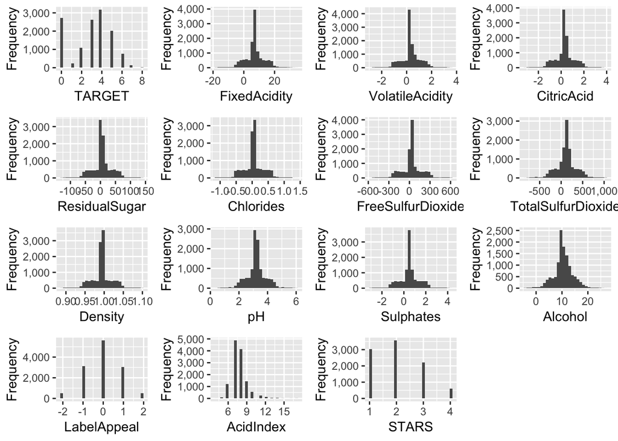

```r
ggtrain = train

plot_histogram(ggtrain)
```

*BoxPlot*

We will do a box plot of the discrete variable and predictor variables.

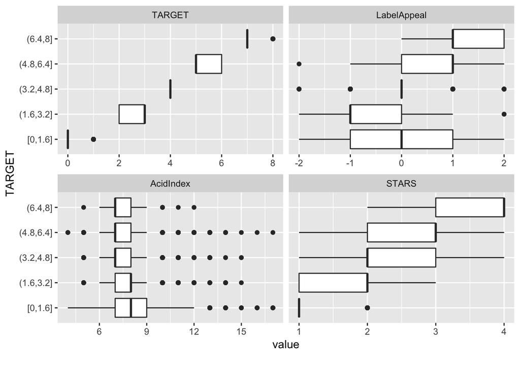

```r
boxtrain = subset(train, select = c('TARGET','LabelAppeal','AcidIndex','STARS'))
plot_boxplot(boxtrain,"TARGET")
```

1. From the box plot we can see higher values of STARS and label Appeal the more cases are bought.

*ScatterPlot*

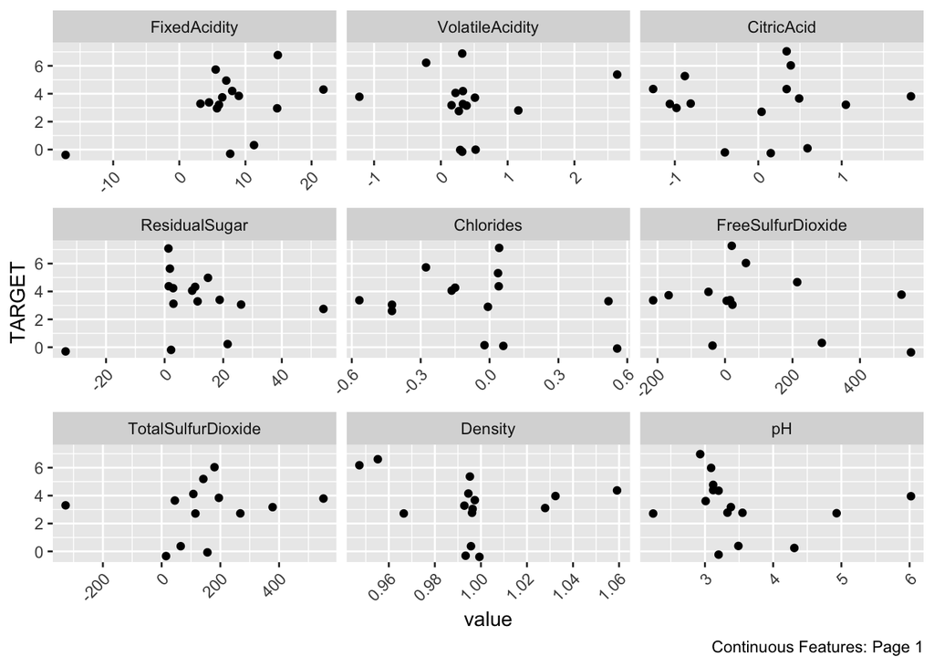

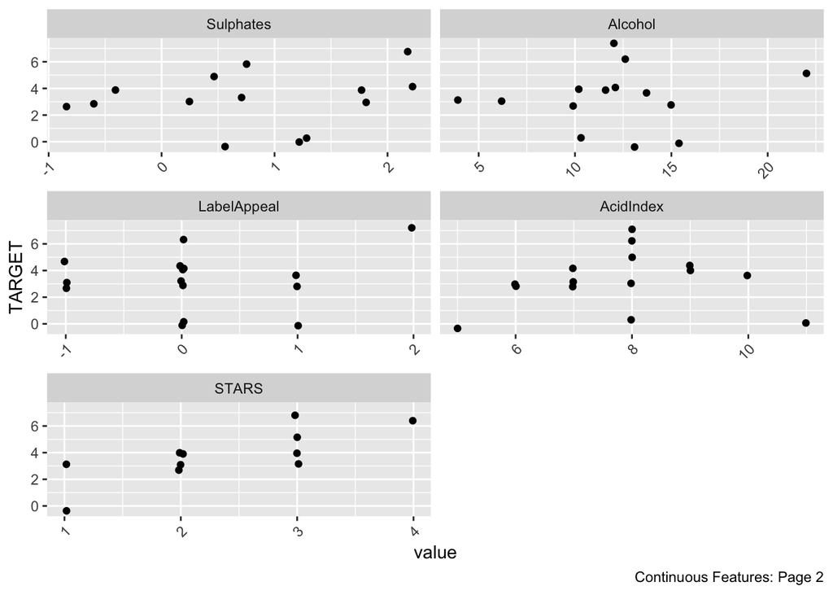

```r
plot_scatterplot(train[1:15,], "TARGET", position = "jitter")
```

From the scatterplot, we do not see any pronounced positive or negative relationships. We will do a Correlation next to see in detail.

*MultiCollinearity between predictor variables and also with response variables*

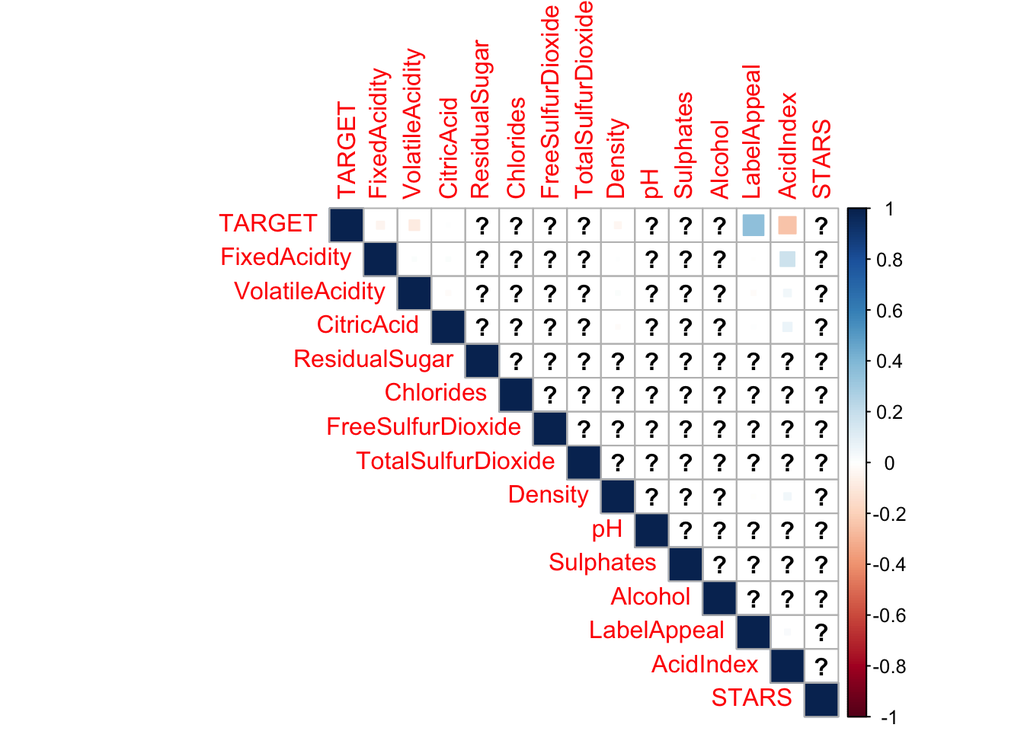

```r
cordata = cor(train)
corrplot(cordata, method = "square", type = "upper")
```

From the corrplot we can see that LabelAppeal and TARGET has a litte positive correlation. AcidIndex and TARGET has a litte negative correlation.

With respect to response and predictor variables, We do not see much of a bigger correlation.

*Missing Value*

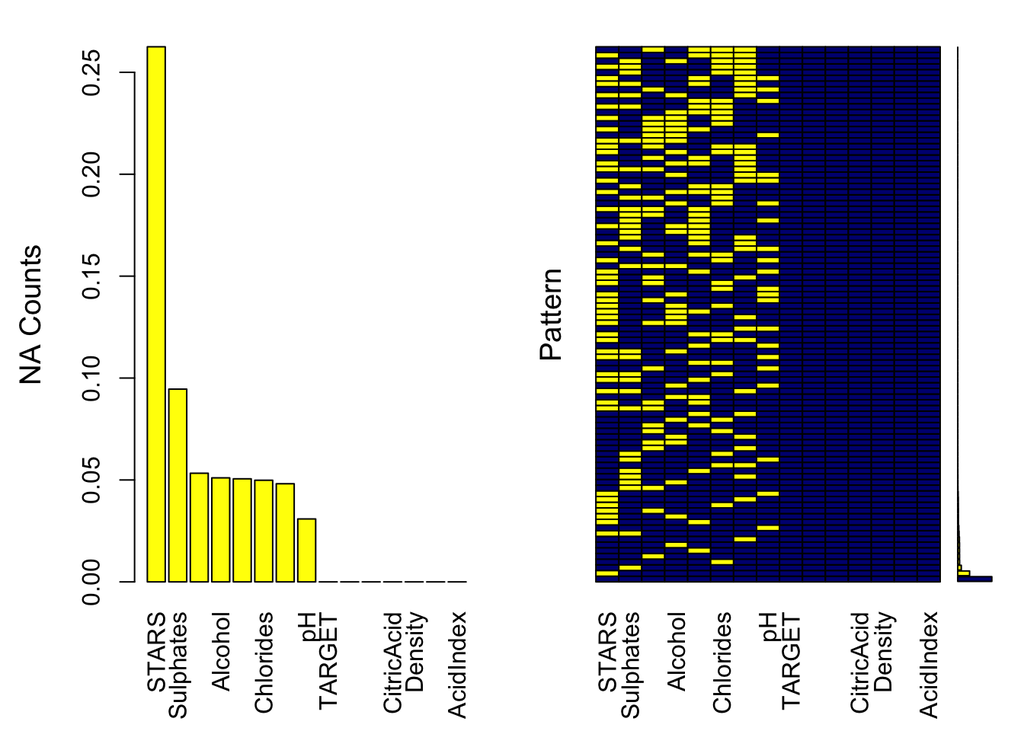

```
##
##  Variables sorted by number of missings:
##            Variable      Count
##               STARS 0.26252442
##           Sulphates 0.09456819
##  TotalSulfurDioxide 0.05330207
##             Alcohol 0.05103556
##   FreeSulfurDioxide 0.05056663
##           Chlorides 0.04986323
##       ResidualSugar 0.04814381
##                  pH 0.03087143
##              TARGET 0.00000000
##        FixedAcidity 0.00000000
##     VolatileAcidity 0.00000000
##          CitricAcid 0.00000000
##             Density 0.00000000
##         LabelAppeal 0.00000000
##           AcidIndex 0.00000000
```

```r
VIM::aggr(train, col=c('navyblue','yellow'),
                      numbers=TRUE, sortVars=TRUE,
                       labels=names(train),
                       ylab=c("NA Counts","Pattern"))
```

## 2.DATA PREPARATION

From our visual exploration we have identified 8 variables are having missing values.

1. We will set Zero for NA values for variable STARS.
2. 10 out of 15 variables has negative values. This shows the data set might not be accurate. We will take an absolute value for these variables.

For rest of the variable which are missing values we can try Random Forrest Algorithm for imputation. In the last excercise we tried executing imputing these random missing values using MICE package. But running the package lead to crashing of R server multiple times. So for that project dropped using mice.

Now for this project we can try using missForest and see the performance.

```r
train$STARS[is.na(train$STARS)] = 0
test$STARS[is.na(test$STARS)] = 0

train =
  train %>%
  mutate(
    FixedAcidity = abs(FixedAcidity),
    VolatileAcidity = abs(VolatileAcidity),
    CitricAcid = abs(CitricAcid),
    ResidualSugar = abs(ResidualSugar),
    Chlorides = abs(Chlorides),
    FreeSulfurDioxide = abs(FreeSulfurDioxide),
    TotalSulfurDioxide = abs(TotalSulfurDioxide),
    Sulphates = abs(Sulphates),
    Alcohol = abs(Alcohol))


test =
  test %>%
  mutate(
    FixedAcidity = abs(FixedAcidity),
    VolatileAcidity = abs(VolatileAcidity),
    CitricAcid = abs(CitricAcid),
    ResidualSugar = abs(ResidualSugar),
    Chlorides = abs(Chlorides),
    FreeSulfurDioxide = abs(FreeSulfurDioxide),
    TotalSulfurDioxide = abs(TotalSulfurDioxide),
    Sulphates = abs(Sulphates),
    Alcohol = abs(Alcohol))
```

We will plot and see the missing elements. This is after filling the missed values.

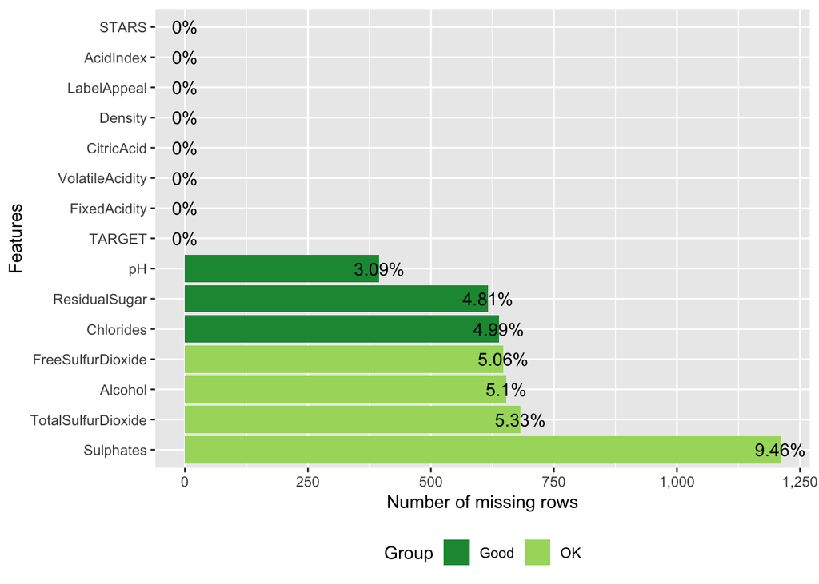

```r
plot_missing(train)
```

If we see below, we are seeing following variables has missing values.

Sulphates TotalSulfurDioxide Alcohol FreeSulfurDioxide Chlorides ResidualSugar pH

For the above we will use the missForest Package and do the imputation.

```r
imputed_train = missForest(train, variablewise = T)
```

```
##   missForest iteration 1 in progress...done!
##   missForest iteration 2 in progress...done!
##   missForest iteration 3 in progress...done!
```

```r
#imputed_train$ximp
train_imputed = imputed_train$ximp

#imputed_train$OOBerror

imputed_eval = missForest(test, variablewise = T)
```

```
##   removed variable(s) 2 due to the missingness of all entries
##   missForest iteration 1 in progress...done!
##   missForest iteration 2 in progress...done!
##   missForest iteration 3 in progress...done!
```

## 3. BUILDING MODELS

### Classification:

As approach we are going to build the following models.

For the following problem we are going to use the Linear Model.

*Base Model and Transformed Variables*

1. The first model will be Base Model. It will contain all transformed imputed data. It contains all the 15 variables.

```r
regbaseplustransform = lm(TARGET ~ .  , data = train_imputed)

summary(regbaseplustransform)
```

```
##
## Call:
## lm(formula = TARGET ~ ., data = train_imputed)
##
## Residuals:
##     Min      1Q  Median      3Q     Max
## -4.4955 -0.9565  0.0609  0.9136  6.0307
##
## Coefficients:
##                      Estimate Std. Error t value Pr(>|t|)
## (Intercept)         4.046e+00  4.504e-01   8.983  < 2e-16 ***
## FixedAcidity        1.993e-06  2.386e-03   0.001 0.999334
## VolatileAcidity    -1.150e-01  2.115e-02  -5.438 5.48e-08 ***
## CitricAcid          3.458e-02  1.937e-02   1.785 0.074297 .
## ResidualSugar      -7.622e-05  4.815e-04  -0.158 0.874242
## Chlorides          -9.900e-02  5.135e-02  -1.928 0.053896 .
## FreeSulfurDioxide   1.960e-04  1.113e-04   1.761 0.078191 .
## TotalSulfurDioxide  2.713e-04  7.400e-05   3.667 0.000247 ***
## Density            -8.400e-01  4.425e-01  -1.898 0.057667 .
## pH                 -3.531e-02  1.756e-02  -2.011 0.044325 *
## Sulphates          -4.485e-02  1.879e-02  -2.386 0.017028 *
## Alcohol             1.236e-02  3.323e-03   3.719 0.000201 ***
## LabelAppeal         4.316e-01  1.369e-02  31.530  < 2e-16 ***
## AcidIndex          -2.103e-01  9.208e-03 -22.834  < 2e-16 ***
## STARS               9.795e-01  1.046e-02  93.660  < 2e-16 ***
## ---
## Signif. codes:  0 '***' 0.001 '**' 0.01 '*' 0.05 '.' 0.1 ' ' 1
##
## Residual standard error: 1.326 on 12780 degrees of freedom
## Multiple R-squared:  0.5266, Adjusted R-squared:  0.5261
## F-statistic:  1016 on 14 and 12780 DF,  p-value: < 2.2e-16
```

*Observations*

FixedAcidity ResidualSugar FreeSulfurDioxide CitricAcid Density

The p-values of LableAppeal, AcidIndex and STARS are very less than 0.05. They have significance impact on the model.

*Base Model Transformation pls Backward Elimination*

The variables discussed above have been removed from base_model variables.

```r
regbasebackward=
lm(formula = TARGET ~ VolatileAcidity + Chlorides + TotalSulfurDioxide +
    pH + Sulphates + Alcohol + LabelAppeal + AcidIndex + STARS,
   data = train_imputed)

summary(regbasebackward)
```

```
##
## Call:
## lm(formula = TARGET ~ VolatileAcidity + Chlorides + TotalSulfurDioxide +
##     pH + Sulphates + Alcohol + LabelAppeal + AcidIndex + STARS,
##     data = train_imputed)
##
## Residuals:
##     Min      1Q  Median      3Q     Max
## -4.5166 -0.9616  0.0610  0.9082  5.9848
##
## Coefficients:
##                      Estimate Std. Error t value Pr(>|t|)
## (Intercept)         3.258e+00  1.071e-01  30.422  < 2e-16 ***
## VolatileAcidity    -1.152e-01  2.115e-02  -5.447 5.21e-08 ***
## Chlorides          -1.013e-01  5.135e-02  -1.972 0.048675 *
## TotalSulfurDioxide  2.724e-04  7.399e-05   3.682 0.000233 ***
## pH                 -3.566e-02  1.756e-02  -2.031 0.042302 *
## Sulphates          -4.460e-02  1.879e-02  -2.374 0.017632 *
## Alcohol             1.230e-02  3.324e-03   3.700 0.000217 ***
## LabelAppeal         4.322e-01  1.369e-02  31.579  < 2e-16 ***
## AcidIndex          -2.106e-01  9.053e-03 -23.263  < 2e-16 ***
## STARS               9.802e-01  1.046e-02  93.730  < 2e-16 ***
## ---
## Signif. codes:  0 '***' 0.001 '**' 0.01 '*' 0.05 '.' 0.1 ' ' 1
##
## Residual standard error: 1.326 on 12785 degrees of freedom
## Multiple R-squared:  0.5263, Adjusted R-squared:  0.5259
## F-statistic:  1578 on 9 and 12785 DF,  p-value: < 2.2e-16
```

*Observations*

From the above model, we see all of our variables has p-values at a significance level lesser than 0.05. This shows the model is very good.

Also this model is parsimonous compared to the Base model.

Let us do some plots and discuss about them.

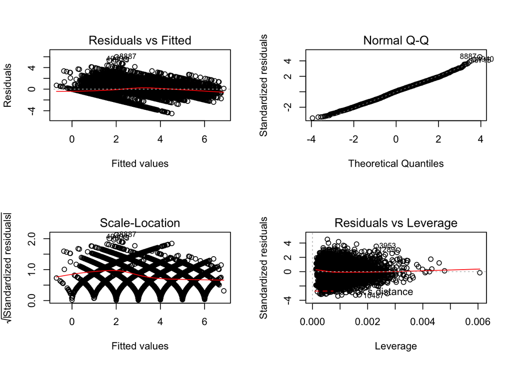

```r
par(mfrow=c(2,2))
plot(regbasebackward)
```

The Q-Q Plot which shows the normality of residual is near normal plot.

Residual vs Fitted plot displays almost constant variance.

```r
knitr::kable(vif(regbasebackward))
```

|  | x |
| --- | --- |
| VolatileAcidity | 1.004768 |
| Chlorides | 1.001960 |
| TotalSulfurDioxide | 1.004674 |
| pH | 1.004882 |
| Sulphates | 1.002757 |
| Alcohol | 1.006506 |
| LabelAppeal | 1.081928 |
| AcidIndex | 1.044674 |
| STARS | 1.119668 |

None of the variables has variance inflation factor > 4. Which indicates it is signficant model compared to base model.

*Step Model*

3. For our next model, we will use the step function on the base model and transformation variables.

```r
base_step_model = step(regbaseplustransform)
```

```
## Start:  AIC=7237.18
## TARGET ~ FixedAcidity + VolatileAcidity + CitricAcid + ResidualSugar +
##     Chlorides + FreeSulfurDioxide + TotalSulfurDioxide + Density +
##     pH + Sulphates + Alcohol + LabelAppeal + AcidIndex + STARS
##
##                      Df Sum of Sq   RSS     AIC
## - FixedAcidity        1       0.0 22473  7235.2
## - ResidualSugar       1       0.0 22474  7235.2
## <none>                            22473  7237.2
## - FreeSulfurDioxide   1       5.5 22479  7238.3
## - CitricAcid          1       5.6 22479  7238.4
## - Density             1       6.3 22480  7238.8
## - Chlorides           1       6.5 22480  7238.9
## - pH                  1       7.1 22481  7239.2
## - Sulphates           1      10.0 22483  7240.9
## - TotalSulfurDioxide  1      23.6 22497  7248.6
## - Alcohol             1      24.3 22498  7249.0
## - VolatileAcidity     1      52.0 22525  7264.8
## - AcidIndex           1     916.8 23390  7746.8
## - LabelAppeal         1    1748.2 24222  8193.7
## - STARS               1   15425.7 37899 13921.8
##
## Step:  AIC=7235.18
## TARGET ~ VolatileAcidity + CitricAcid + ResidualSugar + Chlorides +
##     FreeSulfurDioxide + TotalSulfurDioxide + Density + pH + Sulphates +
##     Alcohol + LabelAppeal + AcidIndex + STARS
##
##                      Df Sum of Sq   RSS     AIC
## - ResidualSugar       1       0.0 22474  7233.2
## <none>                            22473  7235.2
## - FreeSulfurDioxide   1       5.5 22479  7236.3
## - CitricAcid          1       5.6 22479  7236.4
## - Density             1       6.3 22480  7236.8
## - Chlorides           1       6.5 22480  7236.9
## - pH                  1       7.1 22481  7237.2
## - Sulphates           1      10.0 22483  7238.9
## - TotalSulfurDioxide  1      23.6 22497  7246.6
## - Alcohol             1      24.3 22498  7247.0
## - VolatileAcidity     1      52.0 22525  7262.8
## - AcidIndex           1     945.8 23419  7760.6
## - LabelAppeal         1    1748.2 24222  8191.7
## - STARS               1   15427.1 37901 13920.2
##
## Step:  AIC=7233.2
## TARGET ~ VolatileAcidity + CitricAcid + Chlorides + FreeSulfurDioxide +
##     TotalSulfurDioxide + Density + pH + Sulphates + Alcohol +
##     LabelAppeal + AcidIndex + STARS
##
##                      Df Sum of Sq   RSS     AIC
## <none>                            22474  7233.2
## - FreeSulfurDioxide   1       5.5 22479  7234.3
## - CitricAcid          1       5.6 22479  7234.4
## - Density             1       6.3 22480  7234.8
## - Chlorides           1       6.5 22480  7234.9
## - pH                  1       7.1 22481  7235.3
## - Sulphates           1      10.0 22484  7236.9
## - TotalSulfurDioxide  1      23.6 22497  7244.6
## - Alcohol             1      24.3 22498  7245.1
## - VolatileAcidity     1      52.0 22526  7260.8
## - AcidIndex           1     945.7 23419  7758.6
## - LabelAppeal         1    1748.2 24222  8189.7
## - STARS               1   15427.1 37901 13918.3
```

```r
  summary(base_step_model)
```

```
##
## Call:
## lm(formula = TARGET ~ VolatileAcidity + CitricAcid + Chlorides +
##     FreeSulfurDioxide + TotalSulfurDioxide + Density + pH + Sulphates +
##     Alcohol + LabelAppeal + AcidIndex + STARS, data = train_imputed)
##
## Residuals:
##     Min      1Q  Median      3Q     Max
## -4.4938 -0.9561  0.0606  0.9127  6.0318
##
## Coefficients:
##                      Estimate Std. Error t value Pr(>|t|)
## (Intercept)         4.044e+00  4.501e-01   8.985  < 2e-16 ***
## VolatileAcidity    -1.151e-01  2.115e-02  -5.440 5.44e-08 ***
## CitricAcid          3.462e-02  1.937e-02   1.787 0.073903 .
## Chlorides          -9.898e-02  5.135e-02  -1.928 0.053915 .
## FreeSulfurDioxide   1.962e-04  1.113e-04   1.763 0.077957 .
## TotalSulfurDioxide  2.712e-04  7.399e-05   3.665 0.000248 ***
## Density            -8.398e-01  4.424e-01  -1.898 0.057692 .
## pH                 -3.532e-02  1.756e-02  -2.012 0.044288 *
## Sulphates          -4.483e-02  1.879e-02  -2.386 0.017047 *
## Alcohol             1.236e-02  3.323e-03   3.721 0.000199 ***
## LabelAppeal         4.316e-01  1.369e-02  31.533  < 2e-16 ***
## AcidIndex          -2.102e-01  9.065e-03 -23.193  < 2e-16 ***
## STARS               9.795e-01  1.046e-02  93.671  < 2e-16 ***
## ---
## Signif. codes:  0 '***' 0.001 '**' 0.01 '*' 0.05 '.' 0.1 ' ' 1
##
## Residual standard error: 1.326 on 12782 degrees of freedom
## Multiple R-squared:  0.5266, Adjusted R-squared:  0.5262
## F-statistic:  1185 on 12 and 12782 DF,  p-value: < 2.2e-16
```

*Observations*

Also this model is parsimonous compared to the Base model but the backward elimination model was better with 9 variables.

Let us do some plots and discuss about them.

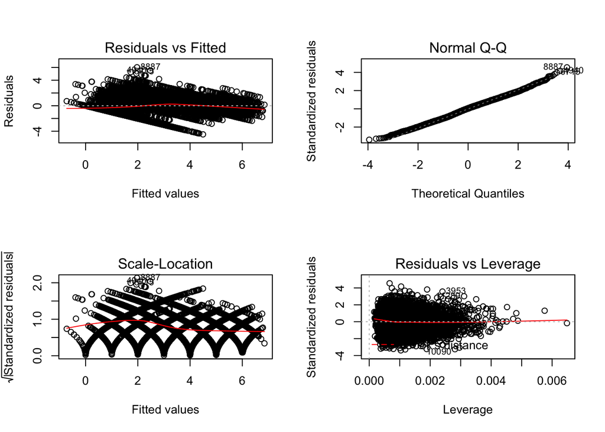

```r
par(mfrow=c(2,2))
plot(base_step_model)
```

The Q-Q Plot which shows the normality of residual is near normal plot.

Residual vs Fitted plot displays almost constant variance. But as the backward elimination the standardized residual displays nonconstant variance.

```r
knitr::kable(vif(base_step_model))
```

|  | x |
| --- | --- |
| VolatileAcidity | 1.004890 |
| CitricAcid | 1.002437 |
| Chlorides | 1.002212 |
| FreeSulfurDioxide | 1.001339 |
| TotalSulfurDioxide | 1.005311 |
| Density | 1.002994 |
| pH | 1.005043 |
| Sulphates | 1.003211 |
| Alcohol | 1.006705 |
| LabelAppeal | 1.082244 |
| AcidIndex | 1.048049 |
| STARS | 1.120177 |

None of the variables has variance inflation factor > 4. Which indicates it is signficant model compared to base model.

*Comparison of Linear Regression Models.*

```r
results = NULL
modellist = list(linearBase = regbaseplustransform, linearBackWard = regbasebackward, LinearBICStep= base_step_model)

for(i in names(modellist)){
    s = summary(modellist[[i]])
    name = i
    mse <- mean(s$residuals^2)
    r2 <- s$r.squared
    f <- s$fstatistic[1]
    k <- s$fstatistic[2]
    n <- s$fstatistic[3]
    results = rbind(results, data.frame(
        name = name, rsquared = r2, mse = mse, f = f,
        k = k, n = n))
}
rownames(results) = NULL
results
```

```
##             name  rsquared      mse        f  k     n
## 1     linearBase 0.5266470 1.756426 1015.634 14 12780
## 2 linearBackWard 0.5262768 1.757800 1578.148  9 12785
## 3  LinearBICStep 0.5266461 1.756429 1185.088 12 12782
```

### Poisson Regression Analysis.

In our experiment the response variable is Count, so the Poisson Regression is the way to go to solve this problem.

As base model we will use the base entire set of variables.

```r
posmod = glm(TARGET ~ ., family = "poisson", data = train_imputed)
summary(posmod)
```

```
##
## Call:
## glm(formula = TARGET ~ ., family = "poisson", data = train_imputed)
##
## Deviance Residuals:
##     Min       1Q   Median       3Q      Max
## -2.9419  -0.7210   0.0674   0.5796   3.2589
##
## Coefficients:
##                      Estimate Std. Error z value Pr(>|z|)
## (Intercept)         1.552e+00  1.960e-01   7.919 2.39e-15 ***
## FixedAcidity       -4.420e-04  1.046e-03  -0.422  0.67270
## VolatileAcidity    -4.160e-02  9.394e-03  -4.429 9.47e-06 ***
## CitricAcid          1.201e-02  8.321e-03   1.444  0.14886
## ResidualSugar       2.791e-05  2.087e-04   0.134  0.89363
## Chlorides          -3.759e-02  2.241e-02  -1.677  0.09346 .
## FreeSulfurDioxide   7.371e-05  4.818e-05   1.530  0.12601
## TotalSulfurDioxide  1.023e-04  3.194e-05   3.203  0.00136 **
## Density            -2.976e-01  1.921e-01  -1.550  0.12124
## pH                 -1.603e-02  7.632e-03  -2.100  0.03571 *
## Sulphates          -1.849e-02  8.272e-03  -2.235  0.02542 *
## Alcohol             2.625e-03  1.445e-03   1.817  0.06917 .
## LabelAppeal         1.330e-01  6.064e-03  21.936  < 2e-16 ***
## AcidIndex          -8.760e-02  4.542e-03 -19.286  < 2e-16 ***
## STARS               3.121e-01  4.527e-03  68.951  < 2e-16 ***
## ---
## Signif. codes:  0 '***' 0.001 '**' 0.01 '*' 0.05 '.' 0.1 ' ' 1
##
## (Dispersion parameter for poisson family taken to be 1)
##
##     Null deviance: 22861  on 12794  degrees of freedom
## Residual deviance: 14750  on 12780  degrees of freedom
## AIC: 46722
##
## Number of Fisher Scoring iterations: 5
```

```r
#knitr::kable(vif(posmod))
```

*Observations*

Deviance is approximately normally distributed since the Median is almost zero.

With p-value of chisq test almost zero, this shows that the deviance is not small enough for a good fit.

```r
cov.m1 = vcovHC(posmod, type="HC0")
std.err = sqrt(diag(cov.m1))
r.est = cbind(Estimate= exp(coef(posmod)), "Robust SE" = std.err,
LL = exp(coef(posmod)) - 1.96 * std.err,
UL = exp(coef(posmod)) + 1.96 * std.err)

r.est
```

```
##                     Estimate    Robust SE        LL        UL
## (Intercept)        4.7218208 1.611464e-01 4.4059739 5.0376677
## FixedAcidity       0.9995581 8.569416e-04 0.9978785 1.0012377
## VolatileAcidity    0.9592487 7.796966e-03 0.9439666 0.9745308
## CitricAcid         1.0120839 6.511023e-03 0.9993223 1.0248455
## ResidualSugar      1.0000279 1.648331e-04 0.9997048 1.0003510
## Chlorides          0.9631085 1.802373e-02 0.9277819 0.9984350
## FreeSulfurDioxide  1.0000737 3.891244e-05 0.9999974 1.0001500
## TotalSulfurDioxide 1.0001023 2.564234e-05 1.0000520 1.0001525
## Density            0.7425736 1.566742e-01 0.4354923 1.0496550
## pH                 0.9840991 6.226214e-03 0.9718957 0.9963025
## Sulphates          0.9816815 6.820061e-03 0.9683141 0.9950488
## Alcohol            1.0026285 1.159980e-03 1.0003550 1.0049021
## LabelAppeal        1.1422739 5.332939e-03 1.1318214 1.1527265
## AcidIndex          0.9161249 4.519860e-03 0.9072659 0.9249838
## STARS              1.3663071 4.766928e-03 1.3569639 1.3756502
```

```r
with(posmod, cbind(res.deviance = deviance, df = df.residual,
  p = pchisq(deviance, df.residual, lower.tail=FALSE)))
```

```
##      res.deviance    df            p
## [1,]     14750.26 12780 3.700549e-32
```

*Poisson Base Step*

We will use the base model and do a step function on it.

```r
posmod = glm(TARGET ~ ., family = "poisson", data = train_imputed)
pos_step_model = step(posmod)
```

```
## Start:  AIC=46722.28
## TARGET ~ FixedAcidity + VolatileAcidity + CitricAcid + ResidualSugar +
##     Chlorides + FreeSulfurDioxide + TotalSulfurDioxide + Density +
##     pH + Sulphates + Alcohol + LabelAppeal + AcidIndex + STARS
##
##                      Df Deviance   AIC
## - ResidualSugar       1    14750 46720
## - FixedAcidity        1    14750 46720
## <none>                     14750 46722
## - CitricAcid          1    14752 46722
## - FreeSulfurDioxide   1    14753 46723
## - Density             1    14753 46723
## - Chlorides           1    14753 46723
## - Alcohol             1    14754 46724
## - pH                  1    14755 46725
## - Sulphates           1    14755 46725
## - TotalSulfurDioxide  1    14760 46730
## - VolatileAcidity     1    14770 46740
## - AcidIndex           1    15140 47110
## - LabelAppeal         1    15231 47201
## - STARS               1    19613 51583
##
## Step:  AIC=46720.3
## TARGET ~ FixedAcidity + VolatileAcidity + CitricAcid + Chlorides +
##     FreeSulfurDioxide + TotalSulfurDioxide + Density + pH + Sulphates +
##     Alcohol + LabelAppeal + AcidIndex + STARS
##
##                      Df Deviance   AIC
## - FixedAcidity        1    14750 46718
## <none>                     14750 46720
## - CitricAcid          1    14752 46720
## - FreeSulfurDioxide   1    14753 46721
## - Density             1    14753 46721
## - Chlorides           1    14753 46721
## - Alcohol             1    14754 46722
## - pH                  1    14755 46723
## - Sulphates           1    14755 46723
## - TotalSulfurDioxide  1    14760 46728
## - VolatileAcidity     1    14770 46738
## - AcidIndex           1    15140 47108
## - LabelAppeal         1    15231 47199
## - STARS               1    19613 51581
##
## Step:  AIC=46718.47
## TARGET ~ VolatileAcidity + CitricAcid + Chlorides + FreeSulfurDioxide +
##     TotalSulfurDioxide + Density + pH + Sulphates + Alcohol +
##     LabelAppeal + AcidIndex + STARS
##
##                      Df Deviance   AIC
## <none>                     14750 46718
## - CitricAcid          1    14752 46719
## - FreeSulfurDioxide   1    14753 46719
## - Density             1    14753 46719
## - Chlorides           1    14753 46719
## - Alcohol             1    14754 46720
## - pH                  1    14755 46721
## - Sulphates           1    14756 46722
## - TotalSulfurDioxide  1    14761 46727
## - VolatileAcidity     1    14770 46736
## - AcidIndex           1    15152 47118
## - LabelAppeal         1    15231 47197
## - STARS               1    19614 51580
```

```r
summary(pos_step_model)
```

```
##
## Call:
## glm(formula = TARGET ~ VolatileAcidity + CitricAcid + Chlorides +
##     FreeSulfurDioxide + TotalSulfurDioxide + Density + pH + Sulphates +
##     Alcohol + LabelAppeal + AcidIndex + STARS, family = "poisson",
##     data = train_imputed)
##
## Deviance Residuals:
##     Min       1Q   Median       3Q      Max
## -2.9486  -0.7205   0.0670   0.5790   3.2639
##
## Coefficients:
##                      Estimate Std. Error z value Pr(>|z|)
## (Intercept)         1.551e+00  1.959e-01   7.920 2.38e-15 ***
## VolatileAcidity    -4.164e-02  9.393e-03  -4.433 9.29e-06 ***
## CitricAcid          1.205e-02  8.319e-03   1.448  0.14759
## Chlorides          -3.758e-02  2.241e-02  -1.677  0.09353 .
## FreeSulfurDioxide   7.371e-05  4.817e-05   1.530  0.12601
## TotalSulfurDioxide  1.023e-04  3.193e-05   3.203  0.00136 **
## Density            -2.973e-01  1.921e-01  -1.548  0.12161
## pH                 -1.606e-02  7.631e-03  -2.105  0.03533 *
## Sulphates          -1.854e-02  8.272e-03  -2.241  0.02502 *
## Alcohol             2.625e-03  1.445e-03   1.817  0.06921 .
## LabelAppeal         1.330e-01  6.064e-03  21.936  < 2e-16 ***
## AcidIndex          -8.788e-02  4.494e-03 -19.558  < 2e-16 ***
## STARS               3.121e-01  4.526e-03  68.956  < 2e-16 ***
## ---
## Signif. codes:  0 '***' 0.001 '**' 0.01 '*' 0.05 '.' 0.1 ' ' 1
##
## (Dispersion parameter for poisson family taken to be 1)
##
##     Null deviance: 22861  on 12794  degrees of freedom
## Residual deviance: 14750  on 12782  degrees of freedom
## AIC: 46718
##
## Number of Fisher Scoring iterations: 5
```

```r
cov.m1 = vcovHC(pos_step_model, type="HC0")
std.err = sqrt(diag(cov.m1))
r.est = cbind(Estimate= exp(coef(pos_step_model)), "Robust SE" = std.err,
LL = exp(coef(pos_step_model)) - 1.96 * std.err,
UL = exp(coef(pos_step_model)) + 1.96 * std.err)

r.est
```

```
##                     Estimate    Robust SE        LL        UL
## (Intercept)        4.7176268 1.610787e-01 4.4019126 5.0333411
## VolatileAcidity    0.9592137 7.797629e-03 0.9439304 0.9744971
## CitricAcid         1.0121204 6.513427e-03 0.9993540 1.0248867
## Chlorides          0.9631176 1.802347e-02 0.9277916 0.9984436
## FreeSulfurDioxide  1.0000737 3.890989e-05 0.9999974 1.0001500
## TotalSulfurDioxide 1.0001023 2.565059e-05 1.0000520 1.0001526
## Density            0.7427932 1.566774e-01 0.4357056 1.0498809
## pH                 0.9840684 6.226014e-03 0.9718654 0.9962713
## Sulphates          0.9816336 6.818756e-03 0.9682688 0.9949984
## Alcohol            1.0026282 1.159981e-03 1.0003546 1.0049017
## LabelAppeal        1.1422691 5.332311e-03 1.1318178 1.1527204
## AcidIndex          0.9158677 4.487033e-03 0.9070731 0.9246623
## STARS              1.3663245 4.766927e-03 1.3569813 1.3756677
```

```r
with(pos_step_model, cbind(res.deviance = deviance, df = df.residual,
  p = pchisq(deviance, df.residual, lower.tail=FALSE)))
```

```
##      res.deviance    df            p
## [1,]     14750.45 12782 4.219555e-32
```

### Negative Binomial Regression Analysis.

As part of Negative Binom, we are going to do BIC on base model.

```r
base_neg_model = glm.nb(TARGET ~ ., data = train_imputed)
step_neg_base_model = step(base_neg_model, k = log(n), trace = 0)
```

[output not shown]

```r
summary(step_neg_base_model)
```

```
##
## Call:
## glm.nb(formula = TARGET ~ VolatileAcidity + TotalSulfurDioxide +
##     LabelAppeal + AcidIndex + STARS, data = train_imputed, init.theta = 48864.60678,
##     link = log)
##
## Deviance Residuals:
##     Min       1Q   Median       3Q      Max
## -3.0071  -0.7177   0.0621   0.5744   3.2582
##
## Coefficients:
##                      Estimate Std. Error z value Pr(>|z|)
## (Intercept)         1.2250113  0.0377618  32.440  < 2e-16 ***
## VolatileAcidity    -0.0418240  0.0093920  -4.453 8.46e-06 ***
## TotalSulfurDioxide  0.0001013  0.0000319   3.174   0.0015 **
## LabelAppeal         0.1329504  0.0060618  21.932  < 2e-16 ***
## AcidIndex          -0.0881713  0.0044692 -19.729  < 2e-16 ***
## STARS               0.3132496  0.0045128  69.413  < 2e-16 ***
## ---
## Signif. codes:  0 '***' 0.001 '**' 0.01 '*' 0.05 '.' 0.1 ' ' 1
##
## (Dispersion parameter for Negative Binomial(48864.61) family taken to be 1)
##
##     Null deviance: 22860  on 12794  degrees of freedom
## Residual deviance: 14773  on 12789  degrees of freedom
## AIC: 46730
##
## Number of Fisher Scoring iterations: 1
##
##
##               Theta:  48865
##           Std. Err.:  50635
## Warning while fitting theta: iteration limit reached
##
##  2 x log-likelihood:  -46715.62
```

```r
#knitr::kable(vif(step_neg_base_model))
```

p-value of all the variables are less than 0.05. This makes the model ideal for prediction.

p-Value from Chi Sq test is almost near zero.

```r
cov.m1 = vcovHC(step_neg_base_model, type="HC0")
std.err = sqrt(diag(cov.m1))
r.est = cbind(Estimate= exp(coef(step_neg_base_model)), "Robust SE" = std.err,
LL = exp(coef(step_neg_base_model)) - 1.96 * std.err,
UL = exp(coef(step_neg_base_model)) + 1.96 * std.err)

r.est
```

```
##                     Estimate    Robust SE        LL        UL
## (Intercept)        3.4042047 3.729522e-02 3.3311061 3.4773033
## VolatileAcidity    0.9590386 7.801479e-03 0.9437477 0.9743295
## TotalSulfurDioxide 1.0001013 2.564525e-05 1.0000510 1.0001515
## LabelAppeal        1.1421934 5.329546e-03 1.1317475 1.1526393
## AcidIndex          0.9156040 4.460662e-03 0.9068611 0.9243469
## STARS              1.3678629 4.752517e-03 1.3585480 1.3771779
```

```r
with(step_neg_base_model, cbind(res.deviance = deviance, df = df.residual,
  p = pchisq(deviance, df.residual, lower.tail=FALSE)))
```

```
##      res.deviance    df            p
## [1,]     14772.81 12789 1.551013e-32
```

## Evalution

```r
#eval_results = predict(base_step_model, newdata = test)
#table(as.integer(eval_results > .5))

#eval_amount = predict(BICBasePlusTransform, test)
```

## References

https://www.analyticsvidhya.com/blog/2016/03/tutorial-powerful-packages-imputing-missing-values/

https://stats.idre.ucla.edu/r/dae/poisson-regression/